# An Overview of Regularized Regression

September 19, 2014

\(\DeclareMathOperator*{\argmin}{arg\,min}\)

## Statistical Learning Group (SLG)

First of three statistical learning topics

- Today: Big picture talk
  - Level of technicality will vary
- Sep. 26: Joshua Day - Comparison of Regularization Penalties
- Oct. 3: ?? - ??

Please provide feedback

- How can the SLG be improved?
- How can I be a more effective presenter?

## Outline

1. Review & Notation
2. Motivation
3. Regularized Regression
4. Implementation

## Review & Notation

## Supervised Learning

Recall from Justin's talk:

- Both inputs (features or predictors) & an output (response) are observed
- Want to build a learner (model) to understand the relationship between the two
  - Often interested in prediction

## Notation

- \({y}_i\): output or response variable
  - \(i = 1,...,n\)
- \(x_{ij}\): input, predictor, or feature variable
  - \(j = 1,...,p\)

Matrix notation

\(\boldsymbol{y} = \begin{pmatrix} y_1 \\ y_2 \\ \vdots \\ y_n \end{pmatrix} \quad\) and \(\quad \boldsymbol{X} = \begin{pmatrix} x_{11} & x_{12} & \cdots & x_{1p} \\ x_{21} & x_{22} & \cdots & x_{2p} \\ \vdots & \vdots & \cdots & \vdots \\ x_{n1} & x_{n2} & \cdots & x_{np} \end{pmatrix}\)

## Predictor Standardization

For regularized regression, predictors should be standardized before estimation

- Done using the classic "z-score" formula
- Puts each predictor on the same scale
  - Mean of 0 and variance of 1
  - Importance will be more clear later
- Use \(\hat{\beta_0} = \bar{y}\) and estimate other coefficients
  - Can transform back to original scale after estimation

## Estimation Goals

Given \(\boldsymbol{X}\), find a function, \(f(\boldsymbol{X})\), to model or predict \(Y\)

- Loss function, \(L(y, f(\boldsymbol{X}))\)
  - Determines adequacy of fit
  - Squared error loss is most common

\[L(y, f(\boldsymbol{X})) = (y - f(\boldsymbol{X}))^2 \]

- Choose \(f\) by minimizing the expected loss \[ E[(Y - f(\boldsymbol{X}))^2] \]
  - \(\Rightarrow f = E[Y | \boldsymbol{X} = \boldsymbol{x}]\)

## Linear Regression

Assume \(E[Y | \boldsymbol{X} = \boldsymbol{x}]\) is a linear function, \(\displaystyle \sum_{j=1}^{p} x_{ij} \beta_j = \boldsymbol{x}_i'\boldsymbol{\beta}\)

- \(Y_i = \beta_0 + x_{i1}\beta_1 + x_{i2}\beta_2 + \dots + x_{ip}\beta_p + \epsilon\)
- Estimate \(\boldsymbol{\beta}\) using ordinary least squares (OLS) \[\hat{\boldsymbol{\beta}} = \argmin_{\boldsymbol{\beta}} \sum_{i=1}^n (y_i - \sum_{j=1}^{p} x_{ij} \beta_j)^2 \\ = \argmin_{\boldsymbol{\beta}} \| \boldsymbol{y} - \boldsymbol{X}\boldsymbol{\beta} \|^2_2\] \[\Rightarrow \hat{\boldsymbol{\beta}}^{OLS} = (\boldsymbol{X}'\boldsymbol{X})^{-1} \boldsymbol{X}'\boldsymbol{y} \Rightarrow \hat{f}(\boldsymbol{x}_i) = \boldsymbol{x}_i'\hat{\boldsymbol{\beta}}\]

## Motivation

### Why is regularization needed?

## Linear Regression Shortcomings

Despite its wide use and elegant theory, linear regession has its shortcomings

- Prediction accuracy
  - Often can be improved upon
- Model interpretability
  - Linear model does not automatically do variable selection

## Assessing Prediction Accuracy

Given a new input, \(\boldsymbol{x}_0\), how do we assess our prediction \(\hat{f}(\boldsymbol{x}_0)\)?

- Expected Prediction Error (EPE)
  - \[ \begin{aligned} EPE(\boldsymbol{x}_0) &= E[(Y_0 - \hat{f}(\boldsymbol{x}_0))^2] \\ &= \text{Var}(\epsilon) + \text{Var}(\hat{f}(\boldsymbol{x}_0)) + \text{Bias}(\hat{f}(\boldsymbol{x}_0))^2 \\ &= \text{Var}(\epsilon) + MSE(\hat{f}(\boldsymbol{x}_0)) \end{aligned} \]
  - \(\text{Var}(\epsilon)\): irreducible error variance
  - \(\text{Var}(\hat{f}(\boldsymbol{x}_0))\): sample-to-sample variability of \(\hat{f}(\boldsymbol{x}_0)\)
  - \(\text{Bias}(\hat{f}(\boldsymbol{x}_0))\): average difference of \(\hat{f}(\boldsymbol{x}_0)\) & \(f(\boldsymbol{x}_0)\)

## Estimating Prediction Error

Common approach to estmating prediction error

- Randomly split data into "training" and "test" sets
  - Test set has \(m\) observations
- Calculate \(\hat{f}\) using training data
- Estimate prediction error using test set MSE \[ \widehat{MSE}(\hat{f}) = \frac{1}{m} \sum_{i=1}^{m} (y_i - \hat{f}(x_i))^2 \]

Why?

- Want our model/predictions to perform well with new/future data

## Bias-Variance Tradeoff

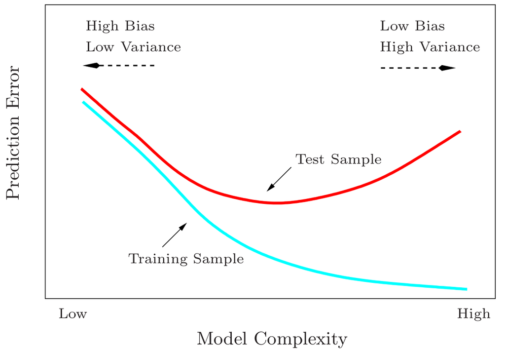

Source: Hastie, Tibshirani, & Friedman (2009)

## Improving Prediction Accuracy

If \(f(x) \approx \text{linear}\), \(\hat{f}\) will have low bias but possibly high variance

- Correlated predictors
- \(p \approx n\) or high-dimensional setting where \(p > n\)

Want to minimize \[MSE(\hat{f}(x)) = \text{Var}(\hat{f}(x)) + \text{Bias}(\hat{f}(x))^2\]

- Sacrifice bias to reduce variance
  - Hopefully leads to decrease in \(MSE\)
- Regularization allows us to tune this trade-off

## Variable Selection

Often interested in using only a subset of the predictors

- Want to identify the most relevant predictors
  - Usually the big picture is of interest
- Helps avoid an overly complex model that is difficult to interpret

Linear regression does not directly determine which predictors to use

How do we choose which predictors to use?

- Theory or expertise
- Ad hoc trial and error using p-values

## Automatic Subset Selection Methods

- Best subset
- Forward or backward stepwise
- Forward stagewise
  - Pick the best subset using test set prediction \(MSE\), \(C_p\), AIC, or BIC

Still not ideal

- Discrete process: predictor is either included or excluded
  - Unstable & highly variable
- Regularization is more continuous, & less variable as a result

## Regularized Regression

### What is regularization?

## Regularization Framework

Same setup as before

- Given \(\boldsymbol{X}\), find a function, \(f(\boldsymbol{X})\), to model or predict \(y\)
- Assume linear model and use squared error loss

Add second term to minimization

\[\hat{\boldsymbol{\beta}}(\lambda) = \argmin_{\beta} \left\{\sum_{i=1}^n (y_i - \sum_{j=1}^{p} x_{ij} \beta_j)^2 + \lambda J(\boldsymbol{\beta})\right\}\]

- \(\lambda \ge 0\) is a regularization (tuning or penalty) parameter
- \(J(\boldsymbol{\beta})\) is a user-defined penalty function
  - Typically, the intercept is not penalized

## Role of the Penalty Term

Consider \(\displaystyle J(\boldsymbol{\beta}) = \sum_{j=1}^p \beta_j^2 = \| \boldsymbol{\beta} \|^2_2 \hspace{0.2cm}\) (Ridge Regression)

Equivalent formulations \[\hat{\boldsymbol{\beta}}(\lambda)^{RR} = \argmin_{\boldsymbol{\beta}} \left\{\sum_{i=1}^n (y_i - \sum_{j=1}^{p} x_{ij} \beta_j)^2 + \lambda \sum_{j=1}^p \beta_j^2 \right\}\]

\[\hat{\boldsymbol{\beta}}(t)^{RR} = \argmin_{\boldsymbol{\beta}} \sum_{i=1}^n (y_i - \sum_{j=1}^{p} x_{ij} \beta_j)^2 \\ \text{subject to} \sum_{j=1}^p \beta_j^2 \le t\]

## Role of the Regularization Parameter

\(\lambda\) directly controls the bias-variance trade-off:

- \(\lambda = 0\) corresponds to OLS
- \(\lambda \rightarrow \infty\) puts more weight on the penalty function and results in more shrinkage of the coefficients
  - Introduce bias at the sake of reducing variance

Each \(\lambda\) results in a different solution \(\hat{\boldsymbol{\beta}}(\lambda)\)

- Choosing \(\lambda\) correctly is crucial (discussed later)

## The Lasso

Tibshirani (1996): Uses \(\displaystyle J(\boldsymbol{\beta}) = \sum_{j=1}^p |\beta_j| = \| \boldsymbol{\beta} \|_1\)

\[\hat{\boldsymbol{\beta}}(\lambda)^{L} = \argmin_{\beta} \left\{\sum_{i=1}^n (y_i - \sum_{j=1}^{p} x_{ij} \beta_j)^2 + \lambda \sum_{j=1}^p |\beta_j| \right\}\]

The subtle change in the penalty makes a big difference

- Not only shrinks coefficients towards zero, but sets some of them to be exactly zero
  - Thus performs continuous variable selection
  - Hence the name, Least Absolute Shrinkage and Selection Operator ([LASSO](http://statweb.stanford.edu/~tibs/lasso.html))

## Geometric Interpretation

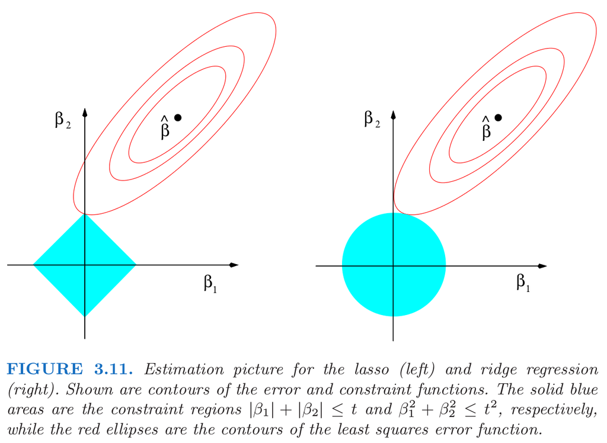

Source: Hastie, Tibshirani, & Friedman (2009)

## General Regularization Framework

\[\min_{f \in \mathcal{H}} \sum_{i=1}^n \left\{L(y_i, f(x_i)) + \lambda J(f)\right\} \]

- \(\mathcal{H}\) is a space of possible functions

Very general and flexible framework

- \(L\): squared error, absolute error, zero-one, negative log-likelihood (GLM), hinge loss (support vector machines), …
- \(J\): ridge regression, lasso, adaptive lasso, group lasso, fused lasso, thesholded lasso, generalized lasso, constrained lasso, elastic-net, dantzig selector, SCAD, smoothing splines, …
  - Allows us to incorporate prior knowledge (sparsity, structure, etc.)

## Implementation

### How is regularization actually used?

## Example: NCAA Dataset

- From Mangold, Bean, & Adams (2003) via [Dr. Dennis Boos](http://www4.stat.ncsu.edu/~boos/var.select/)
- Contains information on 94 major NCAA division I universities
  - \(y\): average 6-year graduation rate for 1996-1998
  - \(bbindex\): author-created basketball index
  - \(attend\): average basketball attendance
  - 17 other predictors suggested by the literature
    - Acceptance rate, student-to-faculty ratio, etc.

Goal: Use OLS, ridge regression, and the lasso to find the best predictive model

Implementation: `glmnet` package in R

- Code available on [SLG Presentations](http://www4.stat.ncsu.edu/~post/reading/pastpresentations)

## Computational Considerations

Regularized regression estimates are a function of \(\lambda\)

Fortunately efficient algorithms exist

- Solution path algorithms
  - LARS Algorithm for the Lasso (Efron et al., 2004)
  - Piecewise linearity (Rosset & Zhu, 2007)
  - Generaic path algorithm (Zhou & Wu, 2013)
- Others
  - Pathwise coordinate descent (Friedman et al., 2007)
  - Alternating Direction Method of Multipliers (ADMM) (Boyd et al. 2011)

## Lasso Solution Path

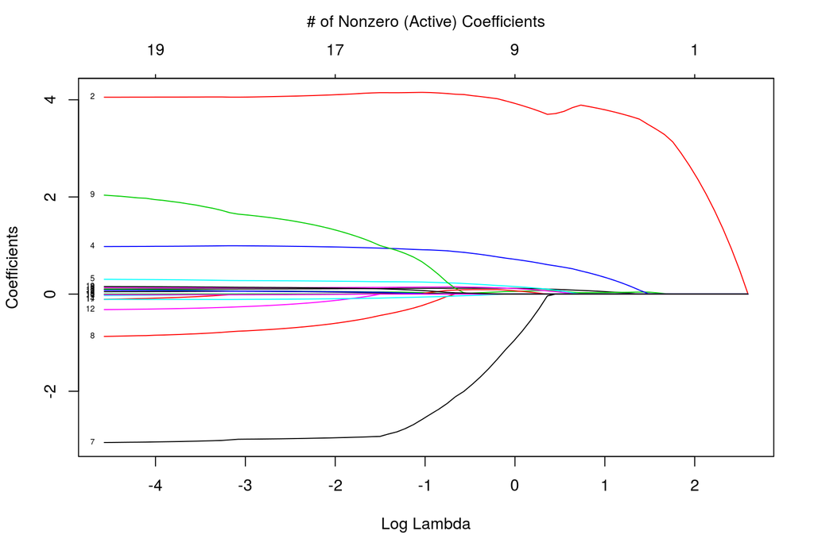

## Ridge Regression Solution Path

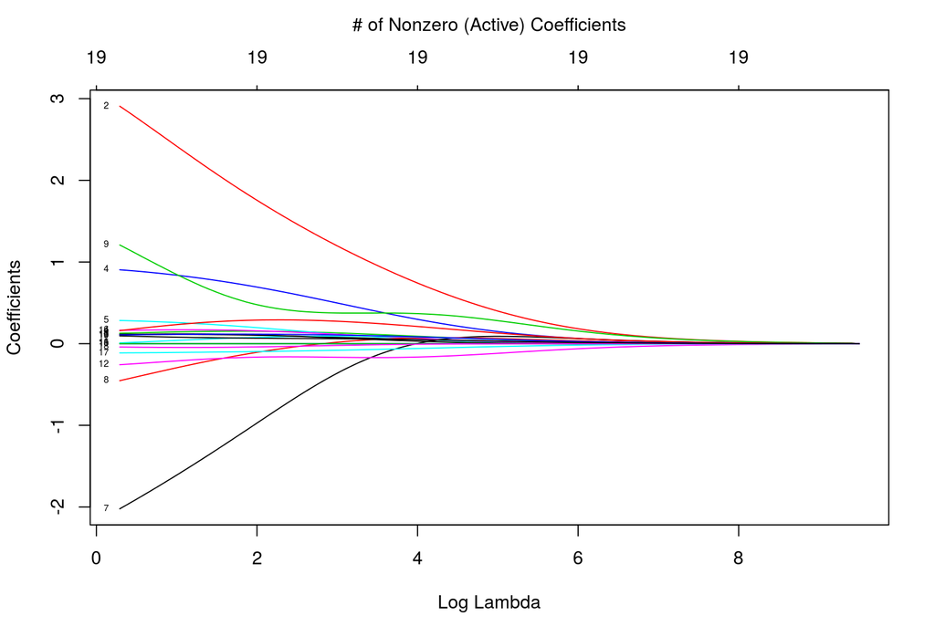

## Choice of Regularization Parameter

Efficiently obtaining the entire solution path is nice, but we still have to choose \(\lambda\)

- Critical since \(\lambda\) constrols the bias-variance tradeoff

Traditional model selection methods

- \(C_p\), AIC, BIC, adjusted \(R^2\)

Cross validation is a popular alternative

- Choice based on predictive performance
- Makes fewer model assumptions
- More widely applicable

## Cross Validation Motivation

Ideally:

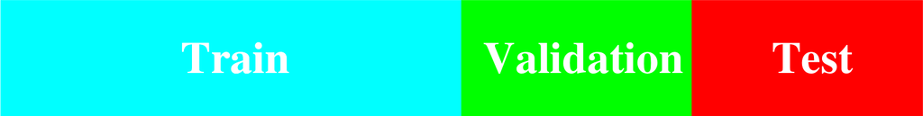

- Separate validation set for choosing \(\lambda\) for a given method
  - Reusing training set encourages overfitting
  - Using test set to pick \(\lambda\) underestimates the true error
- Often we do not have enough data for a seperate validation set
  - Cross validation remedies this problem

## \(K\)-Fold Cross Validation

1. Randomly split training data into \(K\) parts ("folds")

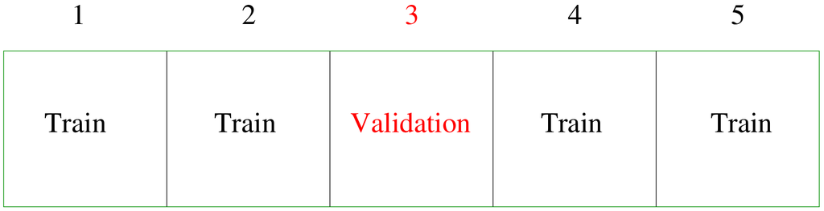

2. Fit model using data in \(K-1\) folds for multiple \(\lambda\text{s}\)
3. Calculate prediction MSE on remaining fold
4. Repeat process for each fold and average the MSEs
- Common choices of \(K\): 5, 10, and \(n\) (leave-one-out CV)
- One standard error rule
  - Choose \(\lambda\) corresponding to smallest model with MSE within one standard error of the minimum MSE

## Lasso 10-Fold Cross Validation

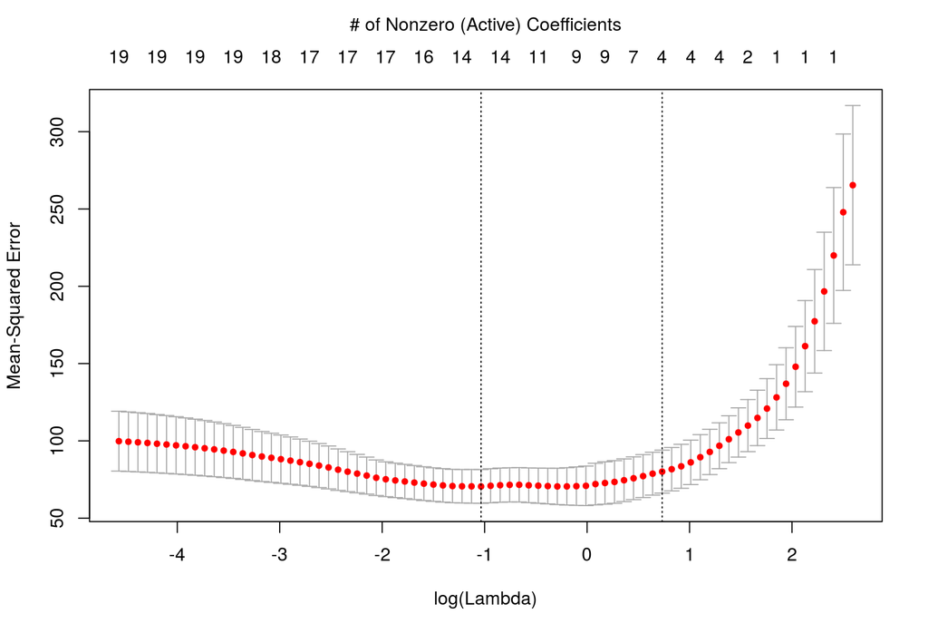

## Final Models

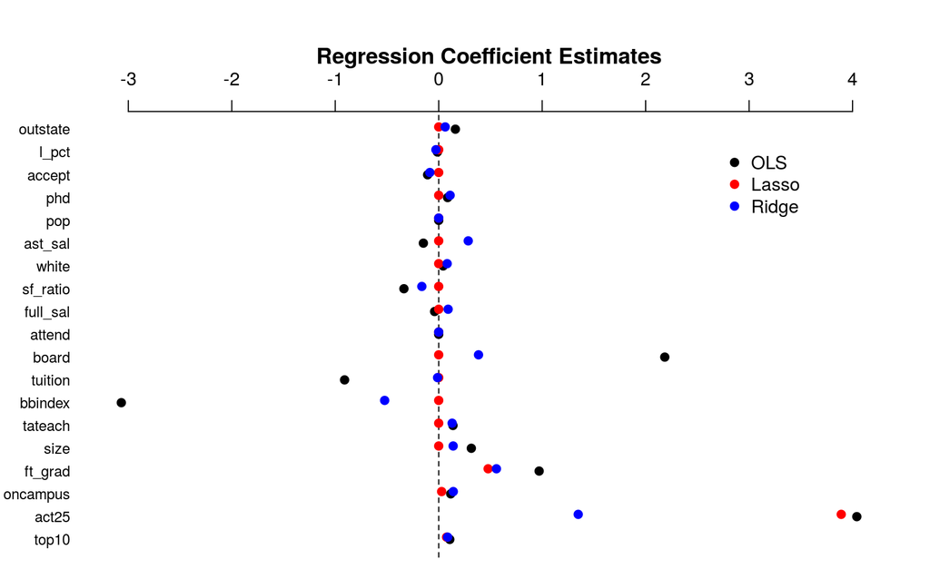

## Model Performance

Test Set MSE

| OLS | Lasso | Ridge |
| --- | --- | --- |
| 77.84 | 62.27 | 47.25 |

## Summary

Traditional linear model is useful but has its shortcomings

- Prediction accuracy
- Model interpretability

Regularization adds a penalty term to the estimation

- Able to exploit the bias-variance trade-off
- Certain penalties allow for continuous variable selection
- Very flexible, able to incorporate prior knowledge

## References

Boyd, S., Parikh, N., Chu, E., Peleato, B., & Eckstein, J. (2011). Distributed optimization and statistical learning via the alternating direction method of multipliers. *Foundations and Trends in Machine Learning*, 3(1), 1-122.

Efron, B., Hastie, T., Johnstone, I., & Tibshirani, R. (2004). Least angle regression. *The Annals of Statistics*, 32(2), 407-499.

Friedman, J., Hastie, T., Höfling, H., & Tibshirani, R. (2007). Pathwise coordinate optimization. *The Annals of Applied Statistics*, 1(2), 302-332.

## References

Mangold, W. D., Bean, L., & Adams, D. (2003). The impact of intercollegiate athletics on graduation rates among major NCAA division I universities: Implications for college persistence theory and practice. *The Journal of Higher Education*, 74(5), 540-562.

Rosset, S., & Zhu, J. (2007). Piecewise linear regularized solution paths. *The Annals of Statistics*, 35(3), 1012-1030.

Tibshirani, R. (1996). Regression shrinkage and selection via the lasso. *Journal of the Royal Statistical Society, Series B*, 58(1), 267-288.

Zhou, H., & Wu, Y. (2013) A generic path algorithm for regularized statistical estimation. *Journal of American Statistical Association*, 109(506): 686-699.